# Snake_mev_analysis

Kevin Healy

05/04/2018

# Summary

This script runs the model which includes error associated with the measurement of LD50 values were this information is reported.

# Upload stuff

## Packages

First the required packages are uploaded. These include .MCMCglmm’ which is used for the main linear analysis, ‘phytools’ and ‘caper’. to handle the phylogenies and finally ‘hdrcde’, ‘wesanderson’ and the ‘MultiDisPlot.R’ function to make some of the plots.

```r
library(phytools)
library(caper)
library(MCMCglmm)
library(wesanderson)
library(hdrcde)
```

```r
source("MultiDisPlot.R")
```

## data

Next we upload the main data file. Only species which had a reported mean yield measure, an LD50 measure and diet with prey item proportions were included. See the methods section in the main paper for a description of the data.

```r
ld50_data <- read.csv("S2_snake_data_5_april.csv",header=T,sep=",")
```

## Phylogeny

We use the phylogeny from Pyron et al 2014 to control for phylogeny in our main model.

```r
tree <- read.tree("liz_and_snake_time_tree.txt")
#this seems to fix a dublicate problem caused by polynomies in the tree
Tree<-makeLabel(tree)
Tree<-makeLabel(Tree)
```

## Convert each value into a standard error term

We collated measures of error associated with LD50 values when reported. All error measures associated with LD50 values were converted to standard error for inclusion as a measurement error term using the `mev` term in the `MCMCglmm` model. Where errors were reported as confidence intervals (Ci) they were log transformed, to correspond with the log transformation of the reposne variable, and converted using $SE = (u - lower Ci_{95})/1.96$ or $SE = (u - lower Ci_{99})/2.58$. For 5% Fiducial limits we treat these as confidence intervals and for ranges we treat these as 99% confidence intervals. Were Standard deviations are given we use the total number of mice given as the sample size to first convert it into a 95% Ci for log trasnformation and then to SE as above.

```r
se_error <- vector()

for(i in 1:length(ld50_data$ld50_error)){

   #95% credability interval
  if(ld50_data$Error_type[i] ==  "95_confidence_interval")
    {se_error[i] <-  ((log10(ld50_data$ld50_mg[i]) - log10(as.numeric(gsub("-.*", "", ld50_data$ld50_error[i])))) / 1.96)}

  #Standard deviation will be left as is unless I can get the number of samples
    else{  if(ld50_data$Error_type[i] ==  "sd")
    {lower95_temp <- (ld50_data$ld50_mg[i] - ((as.numeric(gsub("-.*", "", ld50_data$ld50_error[i])))*1.96)/(4^0.5))

      se_error[i] <-  ((log10(ld50_data$ld50_mg[i]) - log10(lower95_temp)) / 1.96)}

  #for range lets assume a 99% range and a z-value of 2.58
          else{  if(ld50_data$Error_type[i] ==  "max_min" | ld50_data$Error_type[i] ==  "range")
  {se_error[i] <-  ((log10(ld50_data$ld50_mg[i]) - log10(as.numeric(gsub("-.*", "", ld50_data$ld50_error[i])))) / 2.58)}

  #for Fiducial limits we treat them as confidence intervals
                   else{  if(ld50_data$Error_type[i] ==  "5% Fiducial limits")
  {se_error[i] <-  ((log10(ld50_data$ld50_mg[i]) - log10(as.numeric(gsub("-.*", "", ld50_data$ld50_error[i])))) / 1.96)}


                                        else{ se_error[i] <- NA


        }
      }
    }
  }
}
se_error[which(is.na(se_error))] <-  max(na.omit(se_error))
```

## Data transformation

```r
ld50_clean  <- ld50_data

#mass
mass <- log10(ld50_clean $mass_grams)

animal <- ld50_clean $species
species <- ld50_clean $species

##volume
vol.v <- log10(as.numeric(as.vector(ld50_clean $venom_yield_mg)))

#dimension
dimensions <- ld50_clean $dimensions

#LD50
ld50_mg <- log10(as.vector(ld50_clean $ld50_mg))

ld50_method <- ld50_clean $ld50_method

##This just checks if eggs were rcorded within the diet.
eggs <- ld50_clean[,c("eggs")]
egg.bin <- rep(0,length(eggs))

for(i in 1:(length(eggs))){
if(ld50_clean[i,c("eggs")] > 0) egg.bin[i] <- "yes"
else egg.bin[i] <- "no"
}


##This is the weigethed evolutionary distance between prey and diet.
weigted.dist.v <- (ld50_clean$phylo_distance_diet_model_my)/100

##the species habitat
env <- ld50_clean$environment

##whether they constrict
con <- ld50_clean$constriction

##the taxinomic family of the species
fam <- ld50_clean$family

##the class of the model used to measure LD50
mod_class <- ld50_clean$ld50_model_class
```

## full model

Now we set up the model to insure that there is a corresponding animal column within the data frame in order for the phylogeny to match up. We also include as separate “species” term to account for variation associated with multiple measures for a single species.

```r
###full model variables that we want with NA's removed
mydat.max <- na.omit(data.frame(animal,
                        species,
                        mass,
                        weigted.dist.v = weigted.dist.v,
                        dimensions = dimensions,
                        ld50 = ld50_mg,
                        ld50_method,
                        dimensions,
                        egg.bin,
                        env,
                        con,
                        fam,
                        mod_class,
                        se_error = as.vector(se_error)))


###create a dummy variable of just the species we have to prune the phylogeny
spec_dropped <-as.data.frame(matrix(0, nrow = c(length(unique(mydat.max[,"species"]))),
                                    ncol = c(2), dimnames = list(c(),c("species","dummy"))))
spec_dropped[,1] <- unique(mydat.max$species)
spec_dropped[,2] <- rep(0,length = c(length(unique(mydat.max[,"species"]))))
spec_dropped <- as.data.frame(spec_dropped)

max.dat <- comparative.data(data= spec_dropped,
                            phy= Tree,
                            names.col="species",
                            vcv=FALSE)
max.tree <- chronoMPL(max.dat$phy)


max.dropped <- max.dat$dropped$unmatched.rows

mydat.MAX <- mydat.max
if((length(max.dropped) > c(0)) == TRUE){
for(i in 1:(length(max.dropped))){
mydat.MAX <-mydat.MAX[mydat.MAX$species != max.dropped[i],]
}
}


##clean up the final matched data.frame
mydat.MAX <- as.data.frame(as.matrix(mydat.MAX))

mydat.MAX <- data.frame(animal = mydat.MAX$species,
                        species = mydat.MAX$species,
                        mass.aa = (as.numeric(as.character(mydat.MAX$mass))),
                        weigted.dist.v =
                          (as.numeric(as.character(mydat.MAX$weigted.dist.v))),
                        ld50 = (as.numeric(as.character(mydat.MAX$ld50))),
                        ld50_method  = factor(mydat.MAX$ld50_method,
                                              levels = c("sc",
                                                         "iv",
                                                         "ip",
                                                         "im")),
                        dim = mydat.MAX$dimensions,
                        egg.bin = mydat.MAX$egg.bin,
                        env = factor(mydat.MAX$env,
                                     levels = c("terrestrial",
                                                "arboreal",
                                                "aquatic")),
                        con = mydat.MAX$con,
                        fam = mydat.MAX$fam,
                        mod_class = factor(mydat.MAX$mod_class,
                                     levels = c("mammal",
                                                "amphibian",
                                                "artropod",
                                                "bird",
                                                "fish",
                                                "lizard")),
                        se_er = mydat.MAX$se_error)
```

## Set the parameters

Here we set the number of iterations, the thinning and the burn-in

```r
#if you want to include species and ld50 method as a fixed term.

#nitt <- 1200000
#thin <- 500
#burnin <- 200000

nitt <- 12000
thin <- 5
burnin <- 2000
```

## Set the prior

Set the prior. Here we stick with a uninformative prior.

```r
prior<-list(R = list(V = 1, nu=0.002),
            G = list(G1=list(V = 1,
                             n = 1,
                             alpha.mu = rep(0,1),
                             alpha.V= 10^3),
                     G1=list(V = 1,
                             n = 1,
                             alpha.mu = rep(0,1),
                             alpha.V = 10^3)))
```

## Run the full model

```r
full_model <- MCMCglmm(ld50 ~
                         mass.aa +
                         ld50_method +
                         dim +
                         egg.bin +
                         weigted.dist.v +
                         mod_class +
                         con +
                         fam,
                       random = ~ animal +
                                 species,
                       rcov = ~ units,
                       mev = mydat.MAX$se_error,
                       data = mydat.MAX,
                       pedigree = max.tree,
                       prior = prior,
                       family = c("gaussian"),
                       nitt = nitt,
                       thin = thin,
                       burnin = burnin,
                       verbose= FALSE)

summary(full_model)
```

```
##
##  Iterations = 2001:11996
##  Thinning interval  = 5
##  Sample size  = 2000
##
##  DIC: 634.311
##
##  G-structure:  ~animal
##
##        post.mean l-95% CI u-95% CI eff.samp
## animal    0.3851 1.49e-05    0.732    162.5
##
##                ~species
##
##         post.mean  l-95% CI u-95% CI eff.samp
## species   0.06117 2.215e-08   0.1534    135.5
##
##  R-structure:  ~units
##
##       post.mean l-95% CI u-95% CI eff.samp
## units    0.1761   0.1518   0.2013     1674
##
##  Location effects: ld50 ~ mass.aa + ld50_method + dim + egg.bin + weigted.dist.v + mod_class + con + fam
##
##                    post.mean l-95% CI u-95% CI eff.samp  pMCMC
## (Intercept)         -0.44168 -1.71682  0.74598     2000  0.459
## mass.aa              0.26269  0.05707  0.45639     1759  0.006 **
## ld50_methodiv       -0.37734 -0.49818 -0.25543     2000 <5e-04 ***
## ld50_methodip       -0.28739 -0.41261 -0.17016     2000 <5e-04 ***
## ld50_methodim       -0.04355 -0.20886  0.10644     1939  0.578
## dim3                -0.31610 -0.66629  0.05099     1819  0.088 .
## egg.binyes           1.11740  0.61011  1.68535     1779 <5e-04 ***
## weigted.dist.v       0.22285  0.14849  0.29790     1542 <5e-04 ***
## mod_classamphibian   0.79675  0.33282  1.24583     2000 <5e-04 ***
## mod_classartropod    1.99986  1.41012  2.61729     2000 <5e-04 ***
## mod_classbird       -0.74083 -1.00540 -0.52560     2000 <5e-04 ***
## mod_classfish       -0.01912 -0.20503  0.18413     1773  0.844
## mod_classlizard      0.00782 -0.20451  0.22796     2000  0.924
## conyes              -0.13316 -0.66323  0.49597     2000  0.661
## famDipsadidae       -0.45399 -1.83705  0.86125     2242  0.517
## famElapidae         -1.10276 -2.41746  0.10977     2000  0.076 .
## famLamprophiidae    -0.57508 -2.23893  1.02668     2000  0.454
## famNatricidae        0.14852 -1.23993  1.40947     2000  0.815
## famViperidae        -0.33233 -1.74840  1.06275     2245  0.632
## ---
## Signif. codes:  0 '***' 0.001 '**' 0.01 '*' 0.05 '.' 0.1 ' ' 1
```

## Run the full model

```r
ld_50_prop_phlyo <- full_model$VCV[,"animal"]/
                    (full_model$VCV[,"animal"] +
                     full_model$VCV[,"species"] +
                     full_model$VCV[,"units"])

ld_50_prop_species <- full_model$VCV[,"species"]/
                    (full_model$VCV[,"animal"] +
                     full_model$VCV[,"species"] +
                     full_model$VCV[,"units"])

ld_50_prop_units <- full_model$VCV[,"units"]/
                    (full_model$VCV[,"animal"] +
                     full_model$VCV[,"species"] +
                     full_model$VCV[,"units"])

hdr(ld_50_prop_phlyo)
```

```
## $hdr
##           [,1]      [,2]
## 99% 0.03999305 0.8714624
## 95% 0.19545988 0.8541239
## 50% 0.57848376 0.7810249
##
## $mode
## [1] 0.7235403
##
## $falpha
##        1%        5%       50%
## 0.1671883 0.3680007 2.0502988
```

```r
hdr(ld_50_prop_species)
```

```
## $hdr
##             [,1]       [,2]      [,3]      [,4]      [,5]      [,6]
## 99% -0.015743037 0.46009573 0.4667309 0.4736087        NA        NA
## 95% -0.013481305 0.32933339 0.3644933 0.3758512 0.4034846 0.4167855
## 50% -0.004829753 0.08553513        NA        NA        NA        NA
##
## $mode
## [1] 0.006810649
##
## $falpha
##        1%        5%       50%
## 0.2271574 0.4906488 3.8044304
```

```r
hdr(ld_50_prop_units)
```

```
## $hdr
##          [,1]      [,2]
## 99% 0.1310040 0.5249354
## 95% 0.1587928 0.4560073
## 50% 0.2239933 0.3289158
##
## $mode
## [1] 0.2637007
##
## $falpha
##        1%        5%       50%
## 0.2151986 0.8970023 4.0101442
```

### plot the full model

I need to update this table

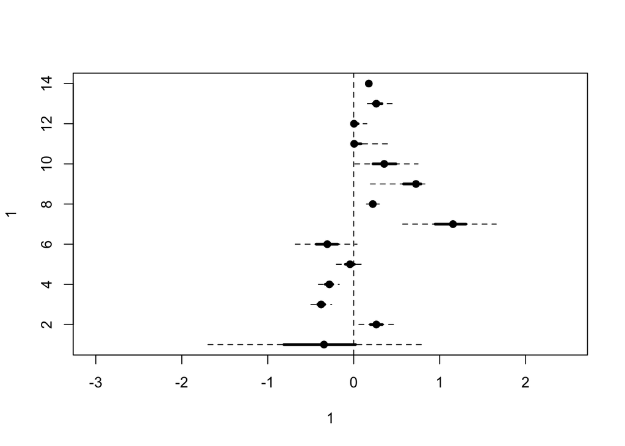

```r
ld50_post <- list(full_model$Sol[,1],
                 full_model$Sol[,"mass.aa"],
                 full_model$Sol[,"ld50_methodiv"],
                 full_model$Sol[,"ld50_methodip"],
                 full_model$Sol[,"ld50_methodim"],
                 full_model$Sol[,"dim3"],
                 full_model$Sol[,"egg.binyes"],
                 full_model$Sol[,"weigted.dist.v"],
                 ld_50_prop_phlyo,
                 full_model$VCV[,"animal"],
                 ld_50_prop_species,
                 full_model$VCV[,"species"],
                 ld_50_prop_units,
                 full_model$VCV[,"units"]
                 )
MultiDisPlot(ld50_post)
abline(v = 0, lty = 2)
```